# Modelling Process

Siwachoat Srisuttiyakorn

2/15/2021

เอกสารนี้แสดงการเขียนคำสั่งใน python เพื่อพัฒนา ML model ทั้ง classification model และ regression model

# **การนำข้อมูลเข้าสู่ python**

การนำข้อมูลเข้าสู่ python สามารถทำได้หลายวิธีการ วิธีการหนึ่งที่คล้ายกับการนำข้อมูลเข้าสู่ R คือการใช้ library-pandas ในตัวอย่างนี้มีข้อมูลตัวอย่าง 2 ไฟล์ ได้แก่ binary.csv และ housing_cleaned.csv การนำไฟล์ข้อมูลทั้งสองเข้าสู่โปรแกรม python สามารถทำได้โดยใช้ฟังก์ชัน read_csv() ซึ่งต้องเรียกผ่าน library pandas ดังตัวอย่างต่อไปนี้

```python
import numpy as np
import pandas as pd
dat_class = pd.read_csv("/Users/siwachoat/Documents/binary.csv") # data for classification
dat_reg = pd.read_csv("/Users/siwachoat/Desktop/housing_cleaned.csv") # data for regression
```

ชุดข้อมูลที่นำเข้าด้วยวิธีการข้างต้นจะอยู่ในรูปแบบของ DataFrame เหมือนกับ data.frame ของโปรแกรม R ผู้วิเคราะห์สามารถตรวจสอบประเภทของตัวแปรที่เก็บไฟล์ข้อมูลดังกล่าวได้โดยใช้ฟังก์ชัน `print(type(dat_class))`

```python
print(type(dat_class))
```

```
## <class 'pandas.core.frame.DataFrame'>
```

นอกจากนี้ยังสามารถสำรวจสภาพทั่วไปของชุดข้อมูลโดยใช้ฟังก์ชัน `head()`, `info()` และ `describe()` ดังตัวอย่างต่อไปนี้

```python
dat_class.head()
```

```
##    admit  gre   gpa  rank
## 0      0  380  3.61     3
## 1      1  660  3.67     3
## 2      1  800  4.00     1
## 3      1  640  3.19     4
## 4      0  520  2.93     4
```

```python
dat_class.info()
```

```
## <class 'pandas.core.frame.DataFrame'>
## RangeIndex: 400 entries, 0 to 399
## Data columns (total 4 columns):
##  #   Column  Non-Null Count  Dtype
## ---  ------  --------------  -----
##  0   admit   400 non-null    int64
##  1   gre     400 non-null    int64
##  2   gpa     400 non-null    float64
##  3   rank    400 non-null    int64
## dtypes: float64(1), int64(3)
## memory usage: 12.6 KB
```

```python
dat_class.describe()
```

```
##             admit         gre         gpa       rank
## count  400.000000  400.000000  400.000000  400.00000
## mean     0.317500  587.700000    3.389900    2.48500
## std      0.466087  115.516536    0.380567    0.94446
## min      0.000000  220.000000    2.260000    1.00000
## 25%      0.000000  520.000000    3.130000    2.00000
## 50%      0.000000  580.000000    3.395000    2.00000
## 75%      1.000000  660.000000    3.670000    3.00000
## max      1.000000  800.000000    4.000000    4.00000
```

จากผลการวิเคราะห์ข้างต้นจะเห็นว่าชุดข้อมูล `dat_class` ประกอบด้วย ตัวแปร 4 ตัว ตัวแปรตามได้แก่ `admit` ที่มีการให้คะแนนสองค่าได้แก่ 0 คือสอบไม่ผ่าน และ 1 คือสอบผ่าน และตัวแปรอิสระที่จะใช้เป็ฯ feature สำหรับจำแนก class ของนักเรียนได้แก่ คะแนนสอบ GRE (`gre`) เกรดเฉลี่ยสะสม (`gpa`) และอันดับของมหาวิทยาลัยที่เลือก (`rank`)

# **Classification Model: K-NN**

หัวข้อนี้จะกล่าวถึงการพัฒนา classification model ด้วยอัลกอริทึม K-Nearest Neighbors (K-NN) อัลกอริทึมนี้เป็นอัลกอริทึมพื้นฐานที่ใช้สำหรับทำนายกลุ่มหรือจำแนกประเภทของหน่วยข้อมูล ซึ่งบ่อยครั้งสามารถทำได้อย่างมีประสิทธิภาพ แนวคิดพื้นฐานของอัลกอริทึม K-NN คือการบันทึกข้อมูล feature และ labels ของหน่วยข้อมูลใน training data เอาไว้ และใช้ข้อมูลที่บันทึกนี้สำหรับการทำนายหน่วยข้อมูลใหม่ โดยจะนำ feature ของหน่วยข้อมูลใหม่มาเปรียบเทียบกับ training data ที่บันทึกเอาไว้ จากนั้นหาหน่วยข้อมูลใน training data ที่มีลักษณะของ feature ใกล้เคียงกับหน่วยข้อมูลใหม่มากที่สุดขึ้นมาจำนวน K ค่า จากนั้นนำ labels ของหน่วยข้อมูลทั้ง K ค่า มาหาฉันทามติซึ่งจะใช้เป็นค่าทำนาย label ของหน่วยข้อมูลใหม่

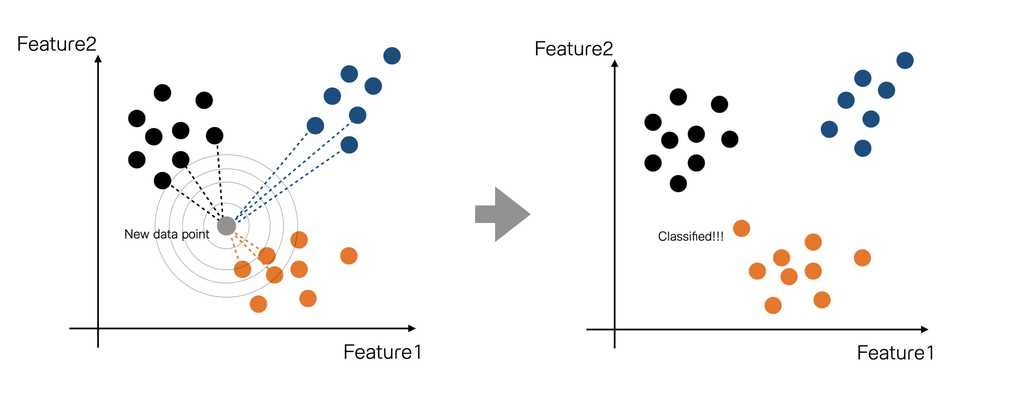

อัลกอริทึม K-NN มี hyperparameter จำนวน 1 ตัว ได้แก่ K หรือจำนวนหน่วยข้อมูลที่มีคุณลักษณะใกล้เคียงกับหน่วยข้อมูลที่ต้องการทำนายมากที่สุด ในทางทฤษฎีค่า K เป็นพารามิเตอร์ที่ใช้กำหนดความซับซ้อนของโมเดล กล่าวคือยิ่ง K มีค่าน้อยโมเดลจะยิ่งมีความยืดหยุ่นหรือมีความไวต่อการเปลี่ยนแปลงในความสัมพันธ์ของข้อมูลมาก ในทางกลับกันหาก K มีค่ามาก อัลกอริทึมจะมีความไวต่อการเปลี่ยนแปลงหรือความสัมพันธ์ของข้อมูลลดลง ทำให้โมเดลมีความซับซ้อนลดลงไปด้วย

การกำหนดค่า K ที่น้อยเกินไปอาจส่งผลให้โมเดลทำนายมีแนวโน้มเป็น overfitting model ในทางกลับกันการกำหนด K ที่มากเกินไปก็อาจส่งผลให้โมเดลทำนายมีแนวโน้มเป็น underfitting model อย่างไรก็ตามการกำหนดค่า K ดังกล่าวไม่สามารถประมาณได้โดยตรงจากข้อมูล ในทางปฏิบัติจะใช้เทคนิคการสุ่มซ้ำ (resampling technique) เช่น cross-validation หรือ bootstrap เพื่อค้นหาและระบุค่า K ที่เหมาะสมมากที่สุด

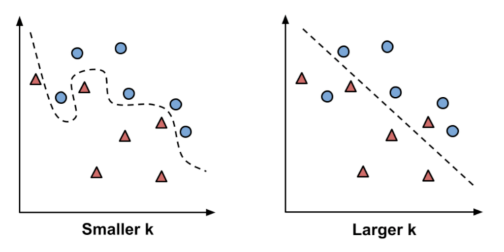

## **Distance matrices**

อัลกอริทึม K-NN จะเปรียบเทียบความต่างหรือความเหมือนของหน่วยข้อมูลใหม่ที่ต้องการทำนาย กับหน่วยข้อมูลในชุดข้อมูลฝึกหัดโดยใช้การวัดระยะทางระหว่างหน่วยข้อมูลบนระนาบของ features ที่ใช้เป็นตัวแทนทำนาย หน่วยข้อมูลที่มีคุณลักษณะหรือค่าของ feature ใกล้เคียงกันจะมีระยะทางบนระนาบดังกล่าวที่ใกล้เคียงกัน ในทางกลับกันหน่วยข้อมูลที่มีคุณลักษณะแตกต่างกันจะมีระยะทางบนระนาบที่ห่างกัน ดังตัวอย่างในรูปด้านล่าง

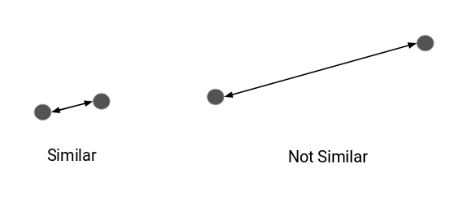

ระยะทางที่ใช้ในอัลกริทึม K-NN มีหลายตัว สมมุติให้ $ x = (x_1, x_2, x_3, …, x_p)$ และ $y=(y_1, y_2, y_3,...,y_p)$ เป็นเวกเตอร์ของ feature ของหน่วยข้อมูลสองหน่วย ได้แก่ หน่วยข้อมูล X และ หน่วยข้อมูล Y

หัวข้อนี้จะกล่าวถึงวิธีการคำนวณระยะทางระหว่างจุดทั้งสองที่สามารถเลือกใช้ได้ทั้งใน python และ R จำนวน 4 วิธีการได้แก่ ระยะทางแบบ Euclidean, Manhattan, Minkowski และ Hamming รายละเอียดมีดังนี้

**ระยะทางแบบ [Euclidean](https://en.wikipedia.org/wiki/Euclidean_distance)**

ระยะแบบ euclidean เป็นระยะที่วัดจากเส้นตรงที่สั้นที่สุดที่สามารถลากเชื่อมต่อระหว่างจุดสองจุดบนระนาบที่กำหนด จากกำหนดจุด X และ Y บนระนาบขนาด p มิติในข้างต้น จะได้ว่าระยะทางแบบ euclidean สามารถคำนวณได้โดยใช้สูตรดังนี้

$d(x,y) = \sqrt{\sum_{i=1}^p(x_i-y_i)^2} = [\sum_{i=1}^p(x_i-y_i)^2]^{\frac{1}{2}}$

รูปด้านล่างแสดงระยะทางแบบ Euclidean แบบ 2 มิติ

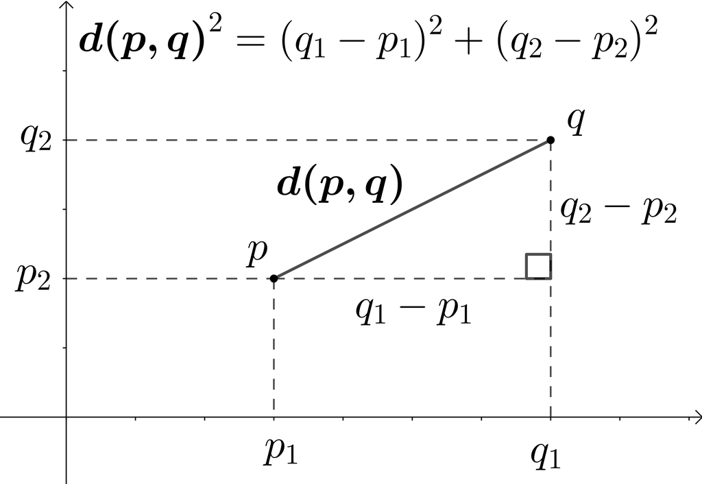

การคำนวณระยะทางแบบ euclidean บนโปรแกรม python สามารถทำได้ง่าย ๆ โดยใช้ library-Scipy โดยที่ library นี้มีฟังก์ชันสำเร็จรูปสำหรับคำนวณระยะทางแบบ euclidean สมมุติว่าต้องการคำนวณระยะห่างระหว่างจุด $x=(1,2,3)$ และ $y=(4,5,6)$ ซึ่งเป็นจุดบนระนาบแบบ 3 มิติสามารถเขียนคำสั่งได้ดังนี้

```python
# importing the library
from scipy.spatial import distance

# defining the points
x = (1,2,3)
y = (4,5,6)
```

```python
x # print x
```

```
## (1, 2, 3)
```

```python
y # print y
```

```
## (4, 5, 6)
```

```python
euclidean_distance = distance.euclidean(x,y)
print("euclidean distance between point x and y is:", round(euclidean_distance,4))
```

```
## euclidean distance between point x and y is: 5.1962
```

**ระยะทางแบบ Manhattan**

ระยะทางแบบ Manhattan เป็นระยะทางที่คำนวณจากผลรวมของค่าสัมบูรณ์ของระยะห่างในแต่ละมิติของจุดที่ต้องการเปรียบเทียบ จากจุด X และ Y ในข้างต้นจะได้ว่า ระยะทางแบบ Manhattan สามารถคำนวณได้โดยใช้สูตรดังนี้

$d(x,y)=\sum_{i=1}^p|x_i-y_i|=|x_1-y_1|+|x_2-y_2|+...+|x_p-y_p|$

รูปต่อไปนี้แสดงตัวอย่างระยะทางแบบ Manhattan ในกรณีที่จุดที่ต้องการเปรียบเทียบอยู่บนระนาบแบบ 2 มิติ

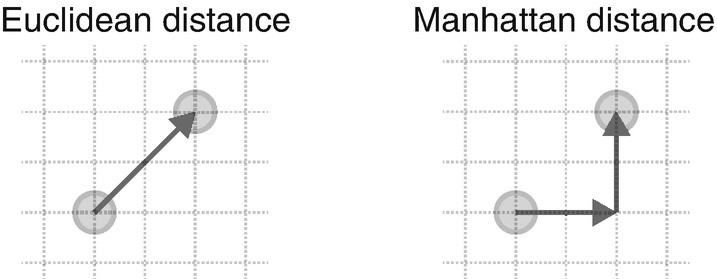

เมื่อเปรียบเทียบระยะทางแบบ Manhattan กับ Euclidean พบว่า ระยะทางแบบ Manhattan มีความแกร่งต่อปัจจัยด้านค่าผิดปกติ (outlier) มากกว่า ทั้งนี้เป็นเพราะไม่ได้มีเทอมยกกำลังสองในสูตรของการคำนวณระยะทาง นอกจากนี้ยังเป็นระยะทางที่เหมาะสำหรับการวิเคราะห์ที่มีจำนวนมิติหรือ feature ที่ใช้ในการวิเคราะห์จำนวนมาก ([Aggarwal, Hinneburg, and Keim, 2001](https://bib.dbvis.de/uploadedFiles/155.pdf))

การคำนวณระยะทางแบบ Manhattan ใน python สามารถดำเนินการได้ดังนี้

```python
## note: Manhattan distance is also known as city clock distance
manhattan_distance = distance.cityblock(x,y)
print("manhattan distance between point x and y is:", round(manhattan_distance,4))
```

```
## manhattan distance between point x and y is: 9
```

**ระยะทาง Minkowski**

ระยะทาง Minkowski เรียกอีกชื่อหนึ่งว่า generalized distance เป็นระยะทางที่เป็นสูตรทั่วไปของระยะทางหลายตัว โดยมีสูตรการคำนวณดังนี้ $d(x,y)=[\sum_{i=1}^p|x_i-y_i|^p]^{\frac{1}{p}}$

จากสูตรข้างต้นเรียกระยะทาง Minkowski อีกชื่อหนึ่งได้ว่า $L_p$ norm distance

- ถ้า $p=1$ ระยะทางแบบ Minkowski จะเทียบเท่ากับระยะทางแบบ Manhattan ซึ่งเรียกอีกชื่อหนึ่งว่า $L_1$ norm distance
- ถ้า $p=2$ ระยะทางแบบ Minkowski จะเทียบเท่ากับระยะทางแบบ Euclidean ในทำนองเดียวกันสามารถเรียกอีกชื่อหนึ่งว่า $L_2$ norm distance
- ถ้า $p \rightarrow \infty$ ระยะทางแบบ Minkowski จะเทียบเท่ากับระยะทางแบบ Chebechev

**ระยะทาง Hamming**

```python
character1 = "datasciences"
character2 = "dataanalysis"

# compute the hamming distance
hamming_distance = distance.hamming(list(character1), list(character2))*len(character1)

print("hamming distance between point character1 and chatacter2 is:", round(hamming_distance,4))
```

```
## hamming distance between point character1 and chatacter2 is: 7.0
```

รูปต่อไปนี้แสดงระยะทาง hamming แบบ 3 มิติ

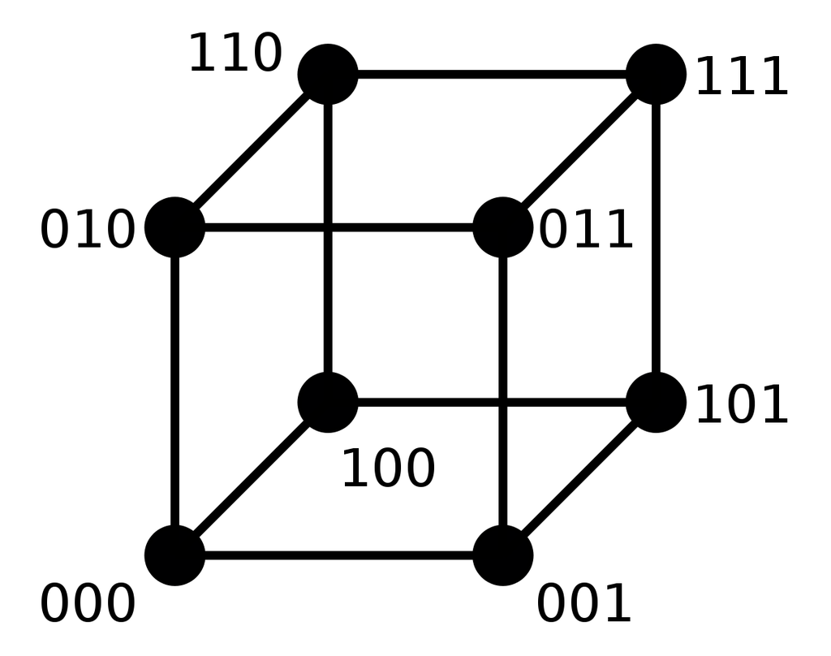

## **Fitting K-NN**

Scikit-learn เป็น library สำคัญตัวหนึ่งของ python ที่มีเครื่องมือจำเป็นและเพียงพอสำหรับการพัฒนา ML model และได้รับความนิยมค่อนข้างมากในปัจจุบันทั้งในภาคการทำงาน และภาคการศึกษา รายละเอียดอื่น ๆ ของ library นี้นิสิตสามารถศึกษาได้จากคู่มือการใช้งานตามลิงค์ —> https://scikit-learn.org/stable/getting_started.html

### splitting data

ขั้นแรกดำเนินการแบ่งชุดข้อมูลออกเป็นสองส่วนได้แก่ training data และ test data ก่อน โดยเขียนคำสั่งดังนี้

```python
from sklearn.model_selection import train_test_split
X = dat_class.iloc[:,1:]
y = dat_class['admit']

# unpack X and y into X_train, X_test, y_train, and y_test
X_train, X_test, y_train, y_test = train_test_split(X,y, test_size=0.2,
                                                    random_state=123,
                                                    stratify = y)
```

ลองตรวจสอบ dimension ของ training และ test data

```python
X_train.shape
```

```
## (320, 3)
```

```python
X_test.shape
```

```
## (80, 3)
```

### **Training K-NN model**

จากนั้นนำอัลกอริทึม K-NN มาเรียนรู้ข้อมูลใน training data ซึ่งมี 2 ขั้นตอน ขั้นแรกคือการระบุโมเดลหรือรายละเอียดของอัลกอริทึม K-NN ที่จะใช้เป็นตัวเรียนรู้ และขั้นที่สองคือการนำอัลกอริทึมที่ระบุมา fit เข้ากับข้อมูล

```python
from sklearn.neighbors import KNeighborsClassifier
knn = KNeighborsClassifier(n_neighbors=6) #model specification
knn.fit(X_train,y_train) # model fitting
```

```
## KNeighborsClassifier(n_neighbors=6)
```

### **Prediction**

การนำอัลกอริทึมที่เรียนรู้แล้วมาทำนายหน่วยข้อมูลใหม่ สามารถทำได้โดยใช้ฟังก์ชัน .predict() ดังนี้

```python
predict_test = knn.predict(X_test)
print("Test set predictions:", predict_test)
```

```
## Test set predictions: [0 0 0 0 0 0 0 0 0 1 1 0 0 0 0 0 1 0 0 0 0 1 0 0 0 1 1 1 0 0 0 0 0 1 0 0 0
##  0 0 0 0 1 0 0 0 1 0 0 0 0 1 1 0 0 0 0 0 0 0 0 0 0 0 0 0 1 0 0 0 0 0 0 0 0
##  1 0 0 0 0 0]
```

### **Measuring model performance**

ในเบื้องต้นผู้วิเคราะห์สามารถคำนวณ metric เพื่อวัดประสิทธิภาพของโมเดลได้โดยเขียนคำสั่งดังนี้

```python
# Confusion Matrix
from sklearn.metrics import confusion_matrix
confusion_matrix(y_test, predict_test)# Accuracy
```

```
## array([[48,  7],
##        [18,  7]])
```

```python
from sklearn.metrics import accuracy_score
accuracy_score(y_test, predict_test)# Recall
```

```
## 0.6875
```

```python
from sklearn.metrics import recall_score
recall_score(y_test, predict_test, average=None)# Precision
```

```
## array([0.87272727, 0.28      ])
```

```python
from sklearn.metrics import precision_score
precision_score(y_test, predict_test, average=None)
```

```
## array([0.72727273, 0.5       ])
```